# Covid-19 SIR Modeling Malaysia

Chan Weng Howe (UTM), Wan Nor Arifin (USM)

Mon, 20 Apr 2020 11:54:03 AM

## Description

This SIR model is modeled by finding the best parameters that fit to Covid-19 Malaysian data up to Mon, 20 Apr 2020.

The SIR model is defined by the following set of ordinary differential equations (Ref: Wikipedia):

$$\frac{dS}{dt} = -\frac{\beta IS}{N} \\
\frac{dI}{dt} = \frac{\beta IS}{N} - \gamma I \\
\frac{dR}{dt} = \gamma I$$
where *S* = Susceptible population, *I* = Infected (active), *R* = Recovered (recover + death), and $N = S(t) + I(t) + R(t)$. $\gamma$ is defined as $\frac{1}{T_r}$, where $T_r$ = time until recovery, which can be obtained from clinical observation. $\beta$ is defines as $\frac{1}{T_c}$, where $T_c$ = time between contacts.

The basic reproduction number, $R_0$ is defined as:

$$R_0 = \frac{\beta}{\gamma}$$
$R_0$ can also be seen as $\frac{T_r}{T_c}$, i.e. the number of contacts before someone recovers, during which he is infectious.

Apart from finding the $\beta$ and $\gamma$ parameter values, experts are concerned about the number of susceptible individuals. Thus, the model is also iterated over decreasing number of initial susceptible individuals (*n*)to find this optimal *n*.

To fit the model to the data, the following weighted loss function is defined, extending the basic residual sum of squares (RSS) formulation:

$$RSS = w_1\sum({ln{I} - ln{\hat I}})^2 + w_2\sum({ln{R} - ln{\hat R}})^2$$
where $w_1$ and $w_2$ allow adjustment of weightage given to *I* or *R* respectively to balance the model fit. We are inclined to give more weight to *I* through $w_1$.

Here, given the limitation of the optimization, one might argue that the *S* found might instead be *E* in SEIR model. This could be explored further in SEIR model, by allowing incubation period in the model. This is beyond the present SIR model to optimize.

## Libraries

```r
library(tidyverse)
library(deSolve)
library(lubridate)
library(ggpubr)
library(plotly)
```

## Data

```r
mys_data = read_csv("https://wnarifin.github.io/covid-19-malaysia/covid-19_my_full.csv") %>% select(1:10) %>% rename(Date = "date")
# mys_data = read_csv("covid-19_my_full.csv") %>% select(1:10)  %>% rename(Date = "date")  # comment out to use local data
# rename date to Date for compatability with original codes

# add active variable
mys_data$active = with(mys_data, total_cases - total_deaths - total_recover)
names(mys_data)
```

```
##  [1] "Date"          "location"      "new_cases"     "new_deaths"
##  [5] "total_cases"   "total_deaths"  "recover"       "total_recover"
##  [9] "icu"           "support"       "active"
```

## Functions

```r
# SIR model
# S - Susceptible, I - Infected, R - Removed (recovered + death), n - initial susceptible population
SIR = function(time, state, parameters) {
  par = as.list(c(state, parameters))
  with(par, {
    dS = (-beta * I * S) / n
    dI = ((beta * I * S) / n) - (gamma * I)
    dR = gamma * I
    list(c(dS, dI, dR))
  })
}

# RSS
RSS = function(parameters) {
  names(parameters) = c("beta","gamma")
  out = ode(y=init, times=Day, func=SIR, parms=parameters)
  fit1 = out[,3]
  fit2 = out[,4]
  w1 = 4
  w2 = 1
  # w1*sum((Active - fit1)^2) + w2*sum((Removed - fit2)^2) # find min RSS on original scale, weighted
  w1*sum((log(Active) - log(fit1))^2) + w2*sum((log(Removed) - log(fit2))^2)  # find min RSS on log scale, weighted
  # give weight to less well predicted curve
}
```

## Parameters

```r
# Uncomment under each header to perform SIR for the period

# Pre MCO #
# name = "Pre MCO"
# start_date  = "2020-03-01"
# end_date    = "2020-03-17"

# MCO All -> Today #
# name = "MCO All"
# start_date  = "2020-03-18"
# end_date    = today()  # will analyze up to max available date

# MCO All minus 1 week #
# name = "MCO All minus 1 week"
# start_date  = "2020-03-18"
# end_date    = "2020-04-07"

# MCO week 2 -> Today # to take into account MCO effect after 1 week
name = "MCO week 2 -> Today"
start_date  = "2020-03-25"
end_date    = today()
# So far, this provides good balance between MCOs

# MCO 1 #
# name = "MCO 1"
# start_date  = "2020-03-18"
# end_date    = "2020-03-31"

# MCO 2 #
# name = "MCO 2"
# start_date  = "2020-04-01"
# end_date    = "2020-04-14"

# MCO 2 -> Today #
# name = "MCO 2 -> Today"
# start_date  = "2020-04-01"
# end_date    = today()

# MCO 2a #
# name = "MCO 2a"
# start_date  = "2020-04-01"
# end_date    = "2020-04-07"

# MCO 2b #
# name = "MCO 2b"
# start_date  = "2020-04-08"
# end_date    = "2020-04-14"

# Basic info from data
Infected   = mys_data %>% filter(Date>=ymd(start_date), Date<=ymd(end_date)) %>% pull(total_cases)
Recovered  = mys_data %>% filter(Date>=ymd(start_date), Date<=ymd(end_date)) %>% pull(total_recover)
Death      = mys_data %>% filter(Date>=ymd(start_date), Date<=ymd(end_date)) %>% pull(total_deaths)
Active     = Infected - Recovered - Death
Removed    = Recovered + Death
Date       = mys_data %>% filter(Date>=ymd(start_date), Date<=ymd(end_date)) %>% pull(Date)
Day        = 1:(length(Date))
```

## Run Optimization for SIR model

```r
# SIR parameters
parameters_values       = c(1/2, 1/14)  # set reasonable start, R0 = 7
parameters_values_lower = c(1/100, 1/19)  # days recover 6 weeks, reduce bound bcs not many severe, observed show quick recovery
parameters_values_upper = c(1, 1/11)  # updated to min 11 days

# Placeholder to ind optimal susceptible population
N_in_steps = data.frame(step=1:7, N=rep(NA,7), Loc=rep(NA,7))

# Initial values
N           = 32.68E6/2  # 4th quarter, 2019
Opt_min_loc = 1  # Optimum minimum n location in output vector
step_i      = 1  # initialize step

# Step 1-7
for (step_i in 1:7) {
  cat("=== Step ", step_i, ": Finding optimal values of beta, gamma and n ===\n", sep ="")
  N = N[Opt_min_loc]  # Susceptible population from previous Step
  # initial susceptible population of Malaysia
  p_start = 0.1
  p_end = 2  # max p of population, also include up direction
  p_step = 0.1
  susceptible = seq(p_start, p_end, p_step)
  N = N * susceptible
  inits = data.frame(S=N-Infected[1]-Recovered[1]-Death[1], I=Infected[1]-Death[1]-Recovered[1], R=Recovered[1]+Death[1])
  Opts = vector("list", length(N))
  for (i in 1:length(N)) {
    n = N[i]
    init = setNames(as.numeric(inits[i,]), c("S", "I", "R"))
    Opt_ = optim(parameters_values, RSS, method = "L-BFGS-B", lower = parameters_values_lower, upper = parameters_values_upper)
    Opts[i]  = list(Opt_)
  }
  Opt_value = sapply(Opts, function(x) x$value)
  Opt_min_loc = which(Opt_value == min(Opt_value))
  N_in_steps[step_i, "N"] = N[Opt_min_loc]
  N_in_steps[step_i, "Loc"] = Opt_min_loc
  cat("=== Found n = ", N[Opt_min_loc], " at location ", Opt_min_loc, " in vector N ===\n\n", sep = "")
  step_i = step_i + 1
  if (step_i == 8) {
    cat("=== Finalizing results =====\n")
    cat("============================\n")
    print(N_in_steps)
  }
}
```

```
## === Step 1: Finding optimal values of beta, gamma and n ===
## === Found n = 1634000 at location 1 in vector N ===
##
## === Step 2: Finding optimal values of beta, gamma and n ===
## === Found n = 163400 at location 1 in vector N ===
##
## === Step 3: Finding optimal values of beta, gamma and n ===
## === Found n = 16340 at location 1 in vector N ===
##
## === Step 4: Finding optimal values of beta, gamma and n ===
## === Found n = 6536 at location 4 in vector N ===
##
## === Step 5: Finding optimal values of beta, gamma and n ===
## === Found n = 6536 at location 10 in vector N ===
##
## === Step 6: Finding optimal values of beta, gamma and n ===
## === Found n = 6536 at location 10 in vector N ===
##
## === Step 7: Finding optimal values of beta, gamma and n ===
## === Found n = 6536 at location 10 in vector N ===
##
## === Finalizing results =====
## ============================
##   step       N Loc
## 1    1 1634000   1
## 2    2  163400   1
## 3    3   16340   1
## 4    4    6536   4
## 5    5    6536  10
## 6    6    6536  10
## 7    7    6536  10
```

```r
# Saving optimized parameters
Opt = Opts[[Opt_min_loc]]
Opt$message  # make sure converge
```

```
## [1] "CONVERGENCE: REL_REDUCTION_OF_F <= FACTR*EPSMCH"
```

```r
Opt_par = setNames(Opt$par, c("beta", "gamma"))
R0 = (Opt_par['beta']/Opt_par['gamma']); names(R0) = "R0"
parameters_values_lower; parameters_values; parameters_values_upper  # just to check whether values in range
```

```
## [1] 0.01000000 0.05263158
```

```
## [1] 0.50000000 0.07142857
```

```
## [1] 1.00000000 0.09090909
```

```r
# Print final parameters
cat("beta = ", Opt_par[['beta']], ", infectious contact rate (/person/day)\n",
    "gamma = ", Opt_par[['gamma']], ", recovery rate (/day)\n",
    "R_0 = ", R0, " number infected/person\n",
    "Recovery days = ", 1/Opt_par[['gamma']], " days",
    sep = "")
```

```
## beta = 0.1736482, infectious contact rate (/person/day)
## gamma = 0.05263158, recovery rate (/day)
## R_0 = 3.299316 number infected/person
## Recovery days = 19 days
```

## Fit Data

```r
# time in days for fitting
t = 1:max(Day)
n = N[Opt_min_loc]
init = setNames(as.numeric(inits[Opt_min_loc,]), c("S", "I", "R"))
# get the fitted values from our SIR model
fitted_projected = data.frame(ode(y=init, times=t, func=SIR, parms=Opt_par))
# add Date, Active, Removed
fitted_projected$Date = Date
fitted_projected$A = Active
fitted_projected$Rm = Removed
fitted_projected
```

```
##    time        S        I         R       Date    A   Rm
## 1     1 4522.000 1578.000  218.0000 2020-03-25 1578  218
## 2     2 4330.227 1683.927  303.8463 2020-03-26 1793  238
## 3     3 4135.037 1787.745  395.2182 2020-03-27 1876  285
## 4     4 3937.938 1888.093  491.9690 2020-03-28 1973  347
## 5     5 3740.476 1983.643  593.8809 2020-03-29 2048  422
## 6     6 3544.183 2073.149  700.6677 2020-03-30 2110  516
## 7     7 3350.526 2155.492  811.9815 2020-03-31 2186  580
## 8     8 3160.864 2229.717  927.4192 2020-04-01 2218  690
## 9     9 2976.411 2295.056 1046.5325 2020-04-02 2299  817
## 10   10 2798.209 2350.953 1168.8383 2020-04-03 2453  880
## 11   11 2627.112 2397.059 1293.8294 2020-04-04 2511  972
## 12   12 2463.782 2433.232 1420.9859 2020-04-05 2596 1066
## 13   13 2308.691 2459.523 1549.7855 2020-04-06 2490 1303
## 14   14 2162.131 2476.156 1679.7135 2020-04-07 2579 1384
## 15   15 2024.231 2483.498 1810.2705 2020-04-08 2567 1552
## 16   16 1894.982 2482.039 1940.9799 2020-04-09 2553 1675
## 17   17 1774.249 2472.357 2071.3934 2020-04-10 2446 1900
## 18   18 1661.806 2455.099 2201.0951 2020-04-11 2462 2068
## 19   19 1557.348 2430.948 2329.7039 2020-04-12 2499 2184
## 20   20 1460.515 2400.609 2456.8757 2020-04-13 2464 2353
## 21   21 1370.910 2364.787 2582.3034 2020-04-14 2427 2560
## 22   22 1288.111 2324.173 2705.7166 2020-04-15 2342 2730
## 23   23 1211.687 2279.432 2826.8808 2020-04-16 2332 2850
## 24   24 1141.208 2231.196 2945.5955 2020-04-17 2198 3053
## 25   25 1076.250 2180.057 3061.6926 2020-04-18 2115 3190
## 26   26 1016.402 2126.564 3175.0340 2020-04-19 2103 3286
```

# Fit measure, log scales

```r
tss1 = sum((log(fitted_projected$A) - mean(log(fitted_projected$A)))^2); tss1
```

```
## [1] 0.3956777
```

```r
rss1 = sum((log(fitted_projected$A) - log(fitted_projected$I))^2); rss1
```

```
## [1] 0.02568831
```

```r
R2_1 = 1 - (rss1 / tss1); R2_1
```

```
## [1] 0.9350777
```

```r
tss2 = sum((log(fitted_projected$Rm) - mean(log(fitted_projected$Rm)))^2); tss2
```

```
## [1] 18.32226
```

```r
rss2 = sum((log(fitted_projected$Rm) - log(fitted_projected$R))^2); rss2
```

```
## [1] 1.140442
```

```r
R2_2 = 1 - (rss2 / tss2); R2_2
```

```
## [1] 0.9377565
```

# Plots

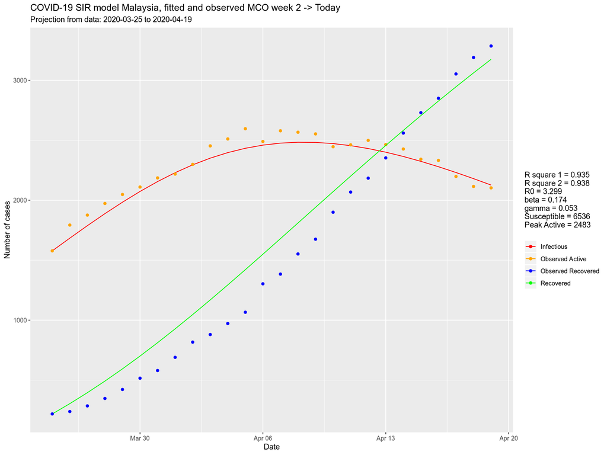

```r
# color settings
colors = c("Susceptible" = "black", "Recovered" = "green", "Infectious" = "red",
           "Observed Active" = "orange", "Observed Recovered" = "blue")

# plot fit the data
fitplot1 = ggplot(fitted_projected, aes(x = Date)) + geom_line(aes(y = I, color = "Infectious")) +
  geom_point(aes(y = A, color = "Observed Active")) + geom_line(aes(y = R, color = "Recovered")) +
  geom_point(aes(y = Rm, color = "Observed Recovered")) +
  labs(y = "Number of cases", title = paste("COVID-19 SIR model Malaysia, fitted and observed", name),
       subtitle = paste("Projection from data:", start_date, "to", fitted_projected$Date[max(Day)]),
       color = paste0("R square 1 = ", round(R2_1,3), "\n",
                      "R square 2 = ", round(R2_2,3), "\n",
                      "R0 = ", round(R0, 3), "\n",
                      "beta = ", round(Opt_par[1], 3), "\n",
                      "gamma = ", round(Opt_par[2], 3), "\n",
                      "Susceptible = ", round(n), "\n",
                      "Peak Active = ", round(max(fitted_projected$I)), "\n")) +
  scale_colour_manual(values = colors)
fitplot1
```

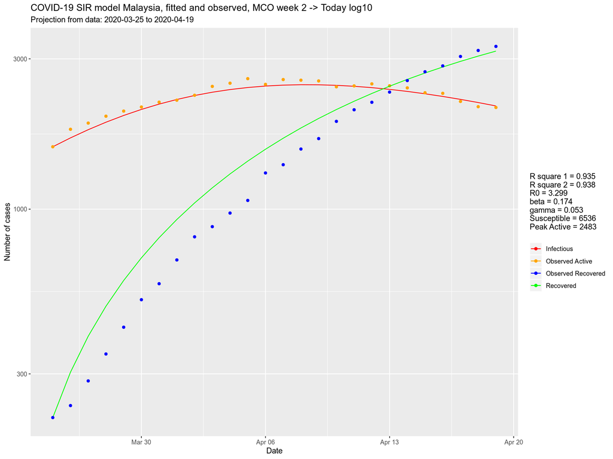

```r
# uncomment ggsave line to save plot in png format, make sure folder "plots_srn" is created
# ggsave(paste0("plots_srn/fit", name, ".png"), width = 12, height = 9)

# plot fit the data, in log10
fitplot1_log = ggplot(fitted_projected, aes(x = Date)) + geom_line(aes(y = I, color = "Infectious")) +
  geom_point(aes(y = A, color = "Observed Active")) + geom_line(aes(y = R, color = "Recovered")) +
  geom_point(aes(y = Rm, color = "Observed Recovered")) + scale_y_log10() +
  labs(y = "Number of cases", title = paste("COVID-19 SIR model Malaysia, fitted and observed,", name, "log10"),
       subtitle = paste("Projection from data:", start_date, "to", fitted_projected$Date[max(Day)]),
       color = paste0("R square 1 = ", round(R2_1,3), "\n",
                      "R square 2 = ", round(R2_2,3), "\n",
                      "R0 = ", round(R0, 3), "\n",
                      "beta = ", round(Opt_par[1], 3), "\n",
                      "gamma = ", round(Opt_par[2], 3), "\n",
                      "Susceptible = ", round(n), "\n",
                      "Peak Active = ", round(max(fitted_projected$I)), "\n")) +
  scale_colour_manual(values = colors)
fitplot1_log
```

```r
# uncomment ggsave line to save plot in png format, make sure folder "plots_srn" is created
# ggsave(paste0("plots_srn/fit", name, "_log.png"), width = 12, height = 9)
```

## Projected Data

```r
# last date to project
last_date = "2020-09-30"
# time in days for predictions
t = 1:as.integer(ymd(last_date) + 1 - ymd(start_date))
# get the fitted values from our SIR model
fitted_projected = data.frame(ode(y=init, times=t, func=SIR, parms=Opt_par))
# add add Date, Active, Removed
fitted_projected$Date = ymd(start_date) + days(t - 1)
fitted_projected$A = c(Active, rep(NA, length(t) - length(Active)))
fitted_projected$Rm = c(Removed, rep(NA, length(t) - length(Active)))
head(fitted_projected, 10); tail(fitted_projected, 10)
```

```
##    time        S        I         R       Date    A  Rm
## 1     1 4522.000 1578.000  218.0000 2020-03-25 1578 218
## 2     2 4330.227 1683.927  303.8463 2020-03-26 1793 238
## 3     3 4135.037 1787.745  395.2182 2020-03-27 1876 285
## 4     4 3937.938 1888.093  491.9690 2020-03-28 1973 347
## 5     5 3740.476 1983.643  593.8809 2020-03-29 2048 422
## 6     6 3544.183 2073.149  700.6677 2020-03-30 2110 516
## 7     7 3350.526 2155.492  811.9815 2020-03-31 2186 580
## 8     8 3160.864 2229.717  927.4192 2020-04-01 2218 690
## 9     9 2976.411 2295.056 1046.5325 2020-04-02 2299 817
## 10   10 2798.209 2350.953 1168.8383 2020-04-03 2453 880
```

```
##     time        S        I        R       Date  A Rm
## 181  181 234.3725 2.219139 6081.408 2020-09-21 NA NA
## 182  182 234.3590 2.118512 6081.522 2020-09-22 NA NA
## 183  183 234.3461 2.022448 6081.631 2020-09-23 NA NA
## 184  184 234.3338 1.930740 6081.735 2020-09-24 NA NA
## 185  185 234.3221 1.843189 6081.835 2020-09-25 NA NA
## 186  186 234.3109 1.759608 6081.930 2020-09-26 NA NA
## 187  187 234.3002 1.679816 6082.020 2020-09-27 NA NA
## 188  188 234.2899 1.603642 6082.106 2020-09-28 NA NA
## 189  189 234.2802 1.530922 6082.189 2020-09-29 NA NA
## 190  190 234.2709 1.461500 6082.268 2020-09-30 NA NA
```

```r
# date of peak active cases
# max_I = which(round(fitted_projected$I) == round(max(fitted_projected$I)))  # at times this works better
max_I = which(fitted_projected$I == max(fitted_projected$I))
max_date = fitted_projected$Date[max_I]
# add cumulative infected cases
fitted_projected$total_infected = fitted_projected$I + fitted_projected$R
# predicted new cases today
new_today = (fitted_projected[fitted_projected$Date == today(), ] - fitted_projected[fitted_projected$Date == today()-1, ])$total_infected
# maximum cumulative cases, date. May add to plot.
fitted_projected$Date[min(which(round(fitted_projected$total_infected) == max(round(fitted_projected$total_infected))))]
```

```
## [1] "2020-09-14"
```

```r
fitted_projected[min(which(round(fitted_projected$total_infected) == max(round(fitted_projected$total_infected)))),]
```

```
##     time        S        I        R       Date  A Rm total_infected
## 174  174 234.4868 3.070814 6080.442 2020-09-14 NA NA       6083.513
```

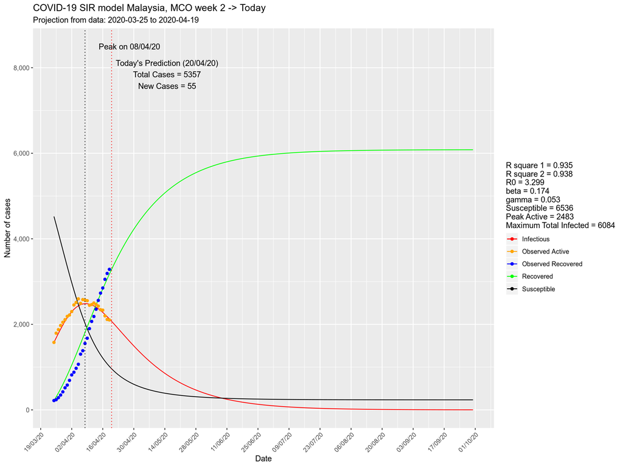

```r
# color settings
colors = c("Susceptible" = "black", "Recovered" = "green", "Infectious" = "red", "Observed Active" = "orange", "Observed Recovered" = "blue")

# plot projection data
sirplot1 = ggplot(fitted_projected, aes(x = Date)) +
  geom_line(aes(y = I, color = "Infectious")) +
  geom_line(aes(y = S, color = "Susceptible")) +
  geom_line(aes(y = R, color = "Recovered")) +
  geom_point(aes(y = A, color = "Observed Active")) +
  geom_point(aes(y = Rm, color = "Observed Recovered")) +
  scale_y_continuous(labels = scales::comma) +
  scale_x_date(date_breaks = "14 day", date_labels = "%d/%m/%y") +
  scale_colour_manual(values = colors) +
  labs(y = "Number of cases", title = paste("COVID-19 SIR model Malaysia,", name),
       subtitle = paste("Projection from data:", start_date, "to", fitted_projected$Date[max(Day)]),
       color = paste0("R square 1 = ", round(R2_1,3), "\n",
                      "R square 2 = ", round(R2_2,3), "\n",
                      "R0 = ", round(R0, 3), "\n",
                      "beta = ", round(Opt_par[1], 3), "\n",
                      "gamma = ", round(Opt_par[2], 3), "\n",
                      "Susceptible = ", round(n), "\n",
                      "Peak Active = ", round(max(fitted_projected$I)), "\n",
                      "Maximum Total Infected = ", round(max(fitted_projected$total_infected)))) +
  geom_vline(xintercept = as.numeric(as.Date(max_date)), linetype = "dotted") +
  annotate(geom = "text", x = as.Date(max_date)+20, y = n*1.3,
           label = paste0("Peak on ", format(max_date, "%d/%m/%y")), angle = 0) +
  geom_vline(xintercept = as.numeric(as.Date(today())), linetype = "dotted", color = "red") +
  annotate(geom = "text", x = as.Date(today())+25, y = n*1.2,
           label = paste0("Today's Prediction (", format(today(), "%d/%m/%y"), ")\n",
                          "Total Cases = ", round(fitted_projected[fitted_projected$Date == today(), "total_infected"]),
                          "\nNew Cases = ", round(new_today)), angle = 0) +
  theme(axis.text.x = element_text(angle = 45, hjust = 1))
sirplot1
```

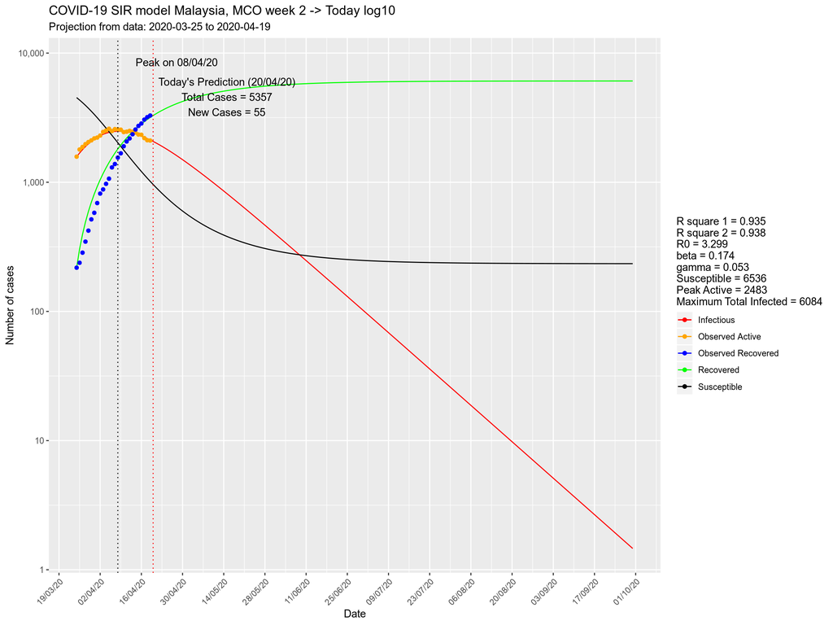

```r
# uncomment ggsave line to save plot in png format, make sure folder "plots_srn" is created
# ggsave(paste0("plots_srn/sir", name, ".png"), width = 12, height = 9)

# plot projection data, in log10
sirplot1_log = ggplot(fitted_projected, aes(x = Date)) +
  geom_line(aes(y = I, color = "Infectious")) +
  geom_line(aes(y = S, color = "Susceptible")) +
  geom_line(aes(y = R, color = "Recovered")) +
  geom_point(aes(y = A, color = "Observed Active")) +
  geom_point(aes(y = Rm, color = "Observed Recovered")) +
  scale_y_log10(labels = scales::comma) +
  scale_x_date(date_breaks = "14 day", date_labels = "%d/%m/%y") +
  scale_colour_manual(values = colors) +
  labs(y = "Number of cases", title = paste("COVID-19 SIR model Malaysia,", name, "log10"),
       subtitle = paste("Projection from data:", start_date, "to", fitted_projected$Date[max(Day)]),
       color = paste0("R square 1 = ", round(R2_1,3), "\n",
                      "R square 2 = ", round(R2_2,3), "\n",
                      "R0 = ", round(R0, 3), "\n",
                      "beta = ", round(Opt_par[1], 3), "\n",
                      "gamma = ", round(Opt_par[2], 3), "\n",
                      "Susceptible = ", round(n), "\n",
                      "Peak Active = ", round(max(fitted_projected$I)), "\n",
                      "Maximum Total Infected = ", round(max(fitted_projected$total_infected)))) +
  geom_vline(xintercept = as.numeric(as.Date(max_date)), linetype = "dotted") +
  annotate(geom = "text", x = as.Date(max_date)+20, y = n*1.3,
           label = paste0("Peak on ", format(max_date, "%d/%m/%y")), angle = 0) +
  geom_vline(xintercept = as.numeric(as.Date(today())), linetype = "dotted", color = "red") +
  annotate(geom = "text", x = as.Date(today())+25, y = n*0.7,
           label = paste0("Today's Prediction (", format(today(), "%d/%m/%y"), ")\n",
                          "Total Cases = ", round(fitted_projected[fitted_projected$Date == today(), "total_infected"]),
                          "\nNew Cases = ", round(new_today)), angle = 0) +
  theme(axis.text.x = element_text(angle = 45, hjust = 1))
sirplot1_log
```

```r
# uncomment ggsave line to save plot in png format, make sure folder "plots_srn" is created
# ggsave(paste0("plots_srn/sir", name, "_log.png"), width = 12, height = 9)
```

## Projection + Asymptomatic

```r
# if 5%, 50%  asymptomatic
# https://www.cebm.net/covid-19/covid-19-what-proportion-are-asymptomatic/

# 1st situation --- #
# get the fitted values from our SIR model
p_asym = .05  # China figure, 5%
n1 = n/(1-p_asym)  # inflate by %
init = c(S=n1-Infected[1]-Recovered[1]-Death[1], I=Infected[1]-Death[1]-Recovered[1], R=Recovered[1]+Death[1])
fitted_projected1 = data.frame(ode(y=init, times=t, func=SIR, parms=Opt_par))
# add a Date & Active
fitted_projected1$Date = ymd(start_date) + days(t - 1)
fitted_projected1$A = c(Active, rep(NA, length(t) - length(Active)))
fitted_projected1$Rm = c(Removed, rep(NA, length(t) - length(Active)))
head(fitted_projected1, 10); tail(fitted_projected1, 10)
```

```
##    time        S        I         R       Date    A  Rm
## 1     1 4866.000 1578.000  218.0000 2020-03-25 1578 218
## 2     2 4658.716 1699.045  304.2383 2020-03-26 1793 238
## 3     3 4445.979 1819.191  396.8309 2020-03-27 1876 285
## 4     4 4229.562 1936.752  495.6866 2020-03-28 1973 347
## 5     5 4011.345 2050.031  600.6245 2020-03-29 2048 422
## 6     6 3793.239 2157.385  711.3754 2020-03-30 2110 516
## 7     7 3577.118 2257.294  827.5871 2020-03-31 2186 580
## 8     8 3364.753 2348.416  948.8312 2020-04-01 2218 690
## 9     9 3157.752 2429.633 1074.6148 2020-04-02 2299 817
## 10   10 2957.516 2500.091 1204.3931 2020-04-03 2453 880
```

```
##     time        S        I        R       Date  A Rm
## 181  181 209.3269 2.136471 6450.537 2020-09-21 NA NA
## 182  182 209.3152 2.038236 6450.647 2020-09-22 NA NA
## 183  183 209.3042 1.944518 6450.751 2020-09-23 NA NA
## 184  184 209.2936 1.855109 6450.851 2020-09-24 NA NA
## 185  185 209.2835 1.769810 6450.947 2020-09-25 NA NA
## 186  186 209.2739 1.688433 6451.038 2020-09-26 NA NA
## 187  187 209.2648 1.610797 6451.124 2020-09-27 NA NA
## 188  188 209.2560 1.536730 6451.207 2020-09-28 NA NA
## 189  189 209.2477 1.466069 6451.286 2020-09-29 NA NA
## 190  190 209.2397 1.398657 6451.362 2020-09-30 NA NA
```

```r
# add cumulative cases
fitted_projected1$total_infected = fitted_projected1$I + fitted_projected1$R
# maximum cumulative cases, date. May add to plot.
fitted_projected1$Date[min(which(round(fitted_projected1$total_infected) == max(round(fitted_projected1$total_infected))))]
```

```
## [1] "2020-09-10"
```

```r
fitted_projected1[min(which(round(fitted_projected1$total_infected) == max(round(fitted_projected1$total_infected)))),]
```

```
##     time        S        I        R       Date  A Rm total_infected
## 170  170 209.4981 3.585524 6448.916 2020-09-10 NA NA       6452.502
```

```r
# --- 2nd situation --- #
# get the fitted values from our SIR model
p_asym = .5  # Iceland figure, 50%
n2 = n/(1-p_asym)  # inflate by %
init = c(S=n2-Infected[1]-Recovered[1]-Death[1], I=Infected[1]-Death[1]-Recovered[1], R=Recovered[1]+Death[1])
fitted_projected2 = data.frame(ode(y=init, times=t, func=SIR, parms=Opt_par))
# add a Date & Active
fitted_projected2$Date = ymd(start_date) + days(t - 1)
fitted_projected2$A = c(Active, rep(NA, length(t) - length(Active)))
fitted_projected2$Rm = c(Removed, rep(NA, length(t) - length(Active)))
head(fitted_projected2, 10); tail(fitted_projected2, 10)
```

```
##    time         S        I         R       Date    A  Rm
## 1     1 11058.000 1578.000  218.0000 2020-03-25 1578 218
## 2     2 10547.102 1995.189  311.7083 2020-03-26 1793 238
## 3     3  9939.220 2485.473  429.3063 2020-03-27 1876 285
## 4     4  9236.723 3042.759  574.5175 2020-03-28 1973 347
## 5     5  8451.517 3651.970  750.5132 2020-03-29 2048 422
## 6     6  7605.624 4288.949  959.4269 2020-03-30 2110 516
## 7     7  6729.332 4922.741 1201.9272 2020-03-31 2186 580
## 8     8  5857.003 5520.029 1476.9680 2020-04-01 2218 690
## 9     9  5021.649 6050.545 1781.8067 2020-04-02 2299 817
## 10   10  4250.055 6491.653 2112.2925 2020-04-03 2453 880
```

```
##     time        S        I        R       Date  A Rm
## 181  181 18.96838 1.649277 12833.38 2020-09-21 NA NA
## 182  182 18.96757 1.565506 12833.47 2020-09-22 NA NA
## 183  183 18.96680 1.485991 12833.55 2020-09-23 NA NA
## 184  184 18.96607 1.410514 12833.62 2020-09-24 NA NA
## 185  185 18.96538 1.338870 12833.70 2020-09-25 NA NA
## 186  186 18.96472 1.270866 12833.76 2020-09-26 NA NA
## 187  187 18.96409 1.206316 12833.83 2020-09-27 NA NA
## 188  188 18.96350 1.145044 12833.89 2020-09-28 NA NA
## 189  189 18.96294 1.086884 12833.95 2020-09-29 NA NA
## 190  190 18.96241 1.031679 12834.01 2020-09-30 NA NA
```

```r
# add cumulative cases
fitted_projected2$total_infected = fitted_projected2$I + fitted_projected2$R
# maximum cumulative cases, date. May add to plot.
fitted_projected2$Date[min(which(round(fitted_projected2$total_infected) == max(round(fitted_projected2$total_infected))))]
```

```
## [1] "2020-07-16"
```

```r
fitted_projected2[min(which(round(fitted_projected2$total_infected) == max(round(fitted_projected2$total_infected)))),]
```

```
##     time        S        I        R       Date  A Rm total_infected
## 114  114 19.48334 54.19864 12780.32 2020-07-16 NA NA       12834.52
```

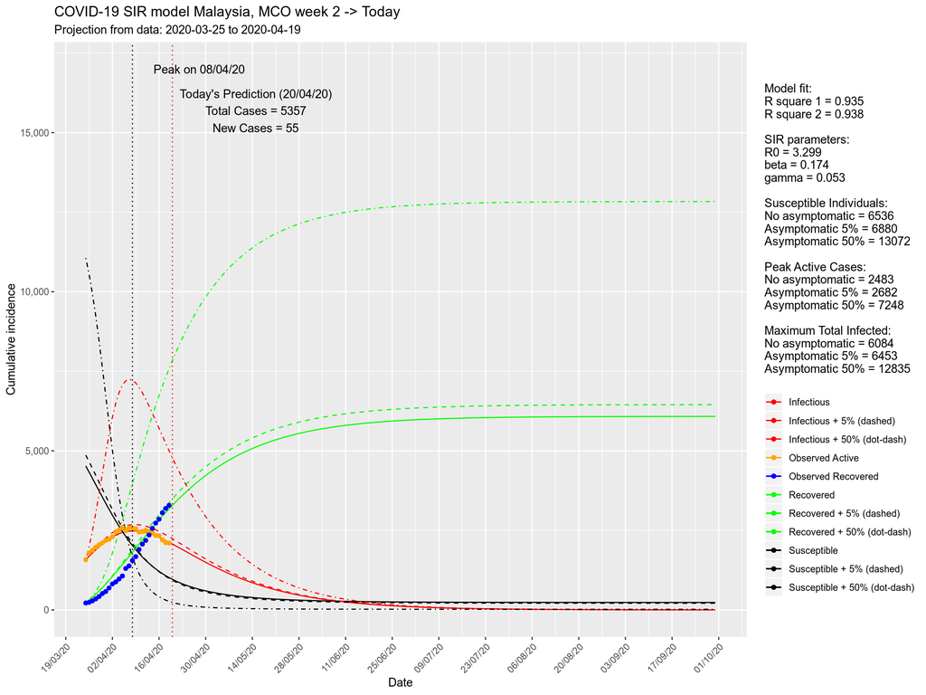

```r
# color settings
colors = c("Susceptible" = "black", "Recovered" = "green", "Infectious" = "red",
           "Susceptible + 5% (dashed)" = "black", "Recovered + 5% (dashed)" = "green", "Infectious + 5% (dashed)" = "red",
           "Susceptible + 50% (dot-dash)" = "black", "Recovered + 50% (dot-dash)" = "green", "Infectious + 50% (dot-dash)" = "red",
           "Observed Active" = "orange", "Observed Recovered" = "blue")

# plot projection data
sirplot2 = ggplot(fitted_projected, aes(x = Date)) +
  geom_line(aes(y = I, color = "Infectious")) +
  geom_line(aes(y = S, color = "Susceptible")) +
  geom_line(aes(y = R, color = "Recovered")) +
  geom_line(data=fitted_projected1, aes(y = I, color = "Infectious + 5% (dashed)"), linetype = "dashed") +
  geom_line(data=fitted_projected1, aes(y = S, color = "Susceptible + 5% (dashed)"), linetype = "dashed") +
  geom_line(data=fitted_projected1, aes(y = R, color = "Recovered + 5% (dashed)"), linetype = "dashed") +
  geom_line(data=fitted_projected2, aes(y = I, color = "Infectious + 50% (dot-dash)"), linetype = "dotdash") +
  geom_line(data=fitted_projected2, aes(y = S, color = "Susceptible + 50% (dot-dash)"), linetype = "dotdash") +
  geom_line(data=fitted_projected2, aes(y = R, color = "Recovered + 50% (dot-dash)"), linetype = "dotdash") +
  geom_point(aes(y = A, color = "Observed Active")) +
  geom_point(aes(y = Rm, color = "Observed Recovered")) +
  scale_y_continuous(labels = scales::comma) +
  scale_x_date(date_breaks = "14 day", date_labels = "%d/%m/%y") +
  scale_colour_manual(values = colors) +
  labs(y = "Cumulative incidence", title = paste("COVID-19 SIR model Malaysia,", name),
       subtitle = paste("Projection from data:", start_date, "to", fitted_projected$Date[max(Day)]),
       color = paste0("Model fit:\n",
                      "R square 1 = ", round(R2_1,3), "\n",
                      "R square 2 = ", round(R2_2,3), "\n\n",
                      "SIR parameters:\n",
                      "R0 = ", round(R0, 3), "\n",
                      "beta = ", round(Opt_par[1], 3), "\n",
                      "gamma = ", round(Opt_par[2], 3), "\n\n",
                      "Susceptible Individuals:\n",
                      "No asymptomatic = ", round(n), "\n",
                      "Asymptomatic 5% = ", round(n1), "\n",
                      "Asymptomatic 50% = ", round(n2), "\n\n",
                      "Peak Active Cases:\n",
                      "No asymptomatic = ", round(max(fitted_projected$I)), "\n",
                      "Asymptomatic 5% = ", round(max(fitted_projected1$I)), "\n",
                      "Asymptomatic 50% = ", round(max(fitted_projected2$I)), "\n\n",
                      "Maximum Total Infected:\n",
                      "No asymptomatic = ", round(max(fitted_projected$total_infected)), "\n",
                      "Asymptomatic 5% = ", round(max(fitted_projected1$total_infected)), "\n",
                      "Asymptomatic 50% = ", round(max(fitted_projected2$total_infected)), "\n")) +
  geom_vline(xintercept = as.numeric(as.Date(max_date)), linetype = "dotted") +
  annotate(geom = "text", x = as.Date(max_date)+20, y = n2*1.3,
           label = paste0("Peak on ", format(max_date, "%d/%m/%y")), angle = 0) +
  geom_vline(xintercept = as.numeric(as.Date(today())), linetype = "dotted", color = "red") +
  annotate(geom = "text", x = as.Date(today())+25, y = n2*1.2,
           label = paste0("Today's Prediction (", format(today(), "%d/%m/%y"), ")\n",
                          "Total Cases = ", round(fitted_projected[fitted_projected$Date == today(), "total_infected"]),
                          "\nNew Cases = ", round(new_today)), angle = 0) +
  theme(axis.text.x = element_text(angle = 45, hjust = 1))
sirplot2
```

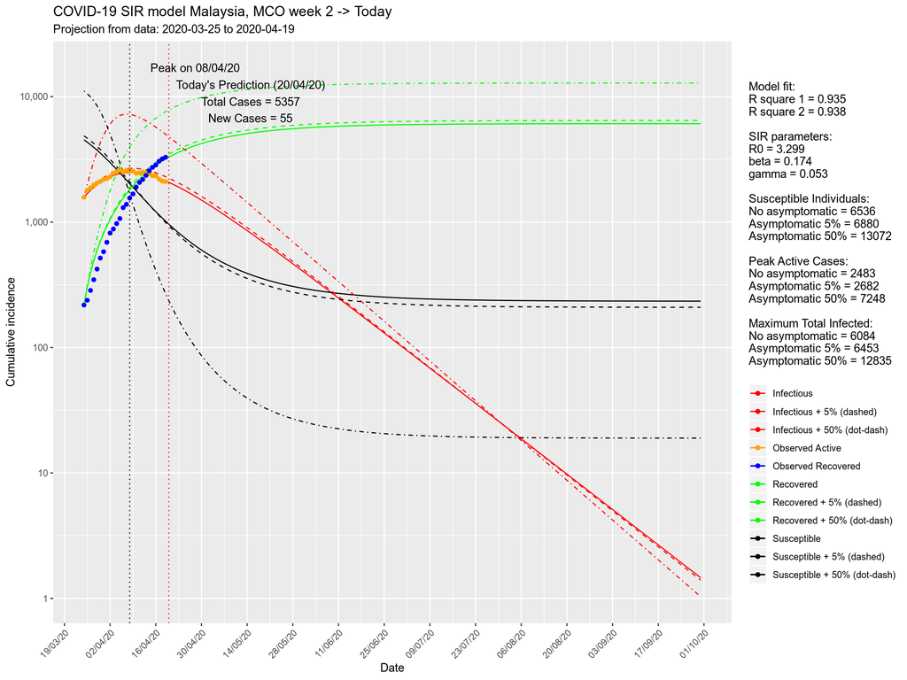

```r
# uncomment ggsave line to save plot in png format, make sure folder "plots_srn" is created
# ggsave(paste0("plots_srn/sir", name, "_asymp.png"), width = 12, height = 9)

# plot projection data, in log10
sirplot2_log = ggplot(fitted_projected, aes(x = Date)) +
  geom_line(aes(y = I, color = "Infectious")) +
  geom_line(aes(y = S, color = "Susceptible")) +
  geom_line(aes(y = R, color = "Recovered")) +
  geom_line(data=fitted_projected1, aes(y = I, color = "Infectious + 5% (dashed)"), linetype = "dashed") +
  geom_line(data=fitted_projected1, aes(y = S, color = "Susceptible + 5% (dashed)"), linetype = "dashed") +
  geom_line(data=fitted_projected1, aes(y = R, color = "Recovered + 5% (dashed)"), linetype = "dashed") +
  geom_line(data=fitted_projected2, aes(y = I, color = "Infectious + 50% (dot-dash)"), linetype = "dotdash") +
  geom_line(data=fitted_projected2, aes(y = S, color = "Susceptible + 50% (dot-dash)"), linetype = "dotdash") +
  geom_line(data=fitted_projected2, aes(y = R, color = "Recovered + 50% (dot-dash)"), linetype = "dotdash") +
  geom_point(aes(y = A, color = "Observed Active")) +
  geom_point(aes(y = Rm, color = "Observed Recovered")) +
  scale_y_log10(labels = scales::comma) +
  scale_x_date(date_breaks = "14 day", date_labels = "%d/%m/%y") +
  scale_colour_manual(values = colors) +
  labs(y = "Cumulative incidence", title = paste("COVID-19 SIR model Malaysia,", name),
       subtitle = paste("Projection from data:", start_date, "to", fitted_projected$Date[max(Day)]),
       color = paste0("Model fit:\n",
                      "R square 1 = ", round(R2_1,3), "\n",
                      "R square 2 = ", round(R2_2,3), "\n\n",
                      "SIR parameters:\n",
                      "R0 = ", round(R0, 3), "\n",
                      "beta = ", round(Opt_par[1], 3), "\n",
                      "gamma = ", round(Opt_par[2], 3), "\n\n",
                      "Susceptible Individuals:\n",
                      "No asymptomatic = ", round(n), "\n",
                      "Asymptomatic 5% = ", round(n1), "\n",
                      "Asymptomatic 50% = ", round(n2), "\n\n",
                      "Peak Active Cases:\n",
                      "No asymptomatic = ", round(max(fitted_projected$I)), "\n",
                      "Asymptomatic 5% = ", round(max(fitted_projected1$I)), "\n",
                      "Asymptomatic 50% = ", round(max(fitted_projected2$I)), "\n\n",
                      "Maximum Total Infected:\n",
                      "No asymptomatic = ", round(max(fitted_projected$total_infected)), "\n",
                      "Asymptomatic 5% = ", round(max(fitted_projected1$total_infected)), "\n",
                      "Asymptomatic 50% = ", round(max(fitted_projected2$total_infected)), "\n")) +
  geom_vline(xintercept = as.numeric(as.Date(max_date)), linetype = "dotted") +
  annotate(geom = "text", x = as.Date(max_date)+20, y = n2*1.3,
           label = paste0("Peak on ", format(max_date, "%d/%m/%y")), angle = 0) +
  geom_vline(xintercept = as.numeric(as.Date(today())), linetype = "dotted", color = "red") +
  annotate(geom = "text", x = as.Date(today())+25, y = n2*0.7,
           label = paste0("Today's Prediction (", format(today(), "%d/%m/%y"), ")\n",
                          "Total Cases = ", round(fitted_projected[fitted_projected$Date == today(), "total_infected"]),
                          "\nNew Cases = ", round(new_today)), angle = 0) +
  theme(axis.text.x = element_text(angle = 45, hjust = 1))
sirplot2_log
```

```r
# uncomment ggsave line to save plot in png format, make sure folder "plots_srn" is created
# ggsave(paste0("plots_srn/sir", name, "_log_asymp.png"), width = 12, height = 9)
```